# Pembukaan

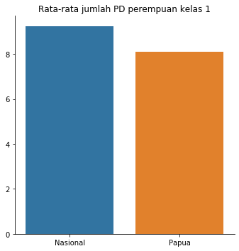

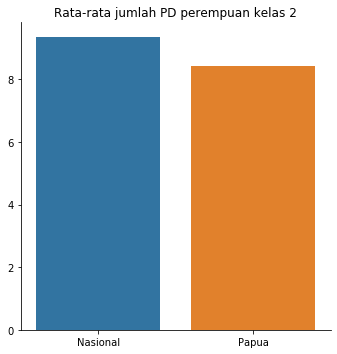

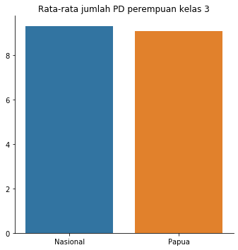

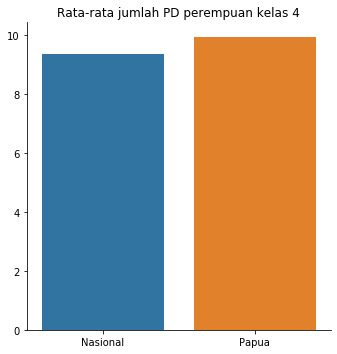

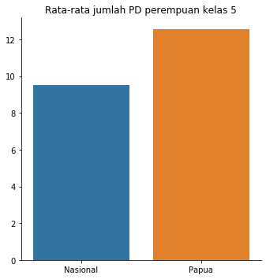

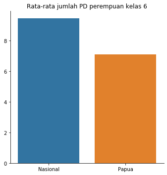

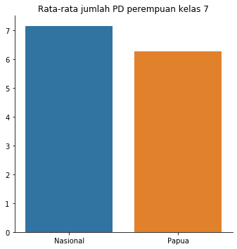

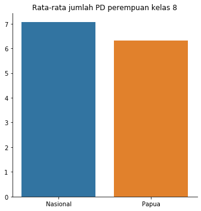

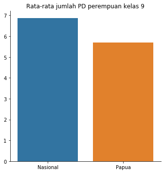

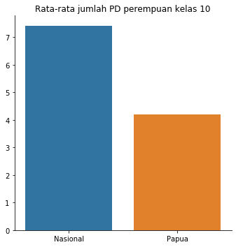

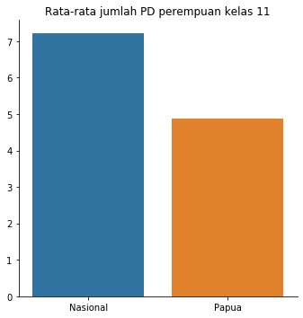

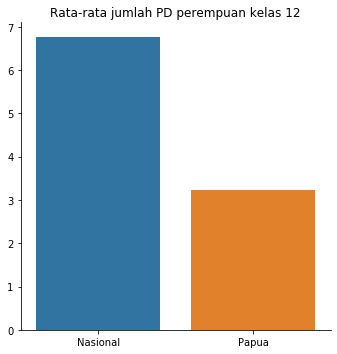

```python
for i in range(1, 13):
    pd_perempuan = get_mean(f'pd_kelas_{i}_perempuan')
    get_bar(pd_perempuan, f'pd_kelas_{i}_perempuan', f'Rata-rata jumlah PD perempuan kelas {i}')
```

### Ruang kelas

```python
get_mean('jml_rk')
```

|  | is_papua | jml_rk |
| --- | --- | --- |
| 0 | False | 8.531072 |
| 1 | True | 7.467290 |

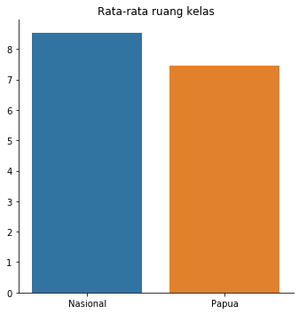

```python
get_bar(get_mean('jml_rk'), 'jml_rk', 'Rata-rata ruang kelas')
```

### Laboratorium

```python
get_mean('jml_lab')
```

|  | is_papua | jml_lab |
| --- | --- | --- |
| 0 | False | 0.713581 |
| 1 | True | 0.481308 |

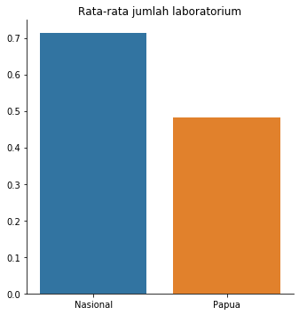

```python
get_bar(get_mean('jml_lab'), 'jml_lab', 'Rata-rata jumlah laboratorium')
```

### Perpustakaan

```python
get_mean('jml_perpus')
```

|  | is_papua | jml_perpus |
| --- | --- | --- |
| 0 | False | 0.810530 |
| 1 | True | 0.551402 |

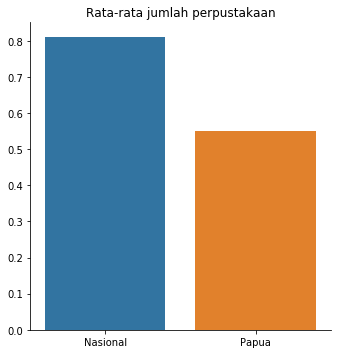

```python
get_bar(get_mean('jml_perpus'), 'jml_perpus', 'Rata-rata jumlah perpustakaan')
```

### Kecukupan air

```python
set(df['kecukupan_air'])
```

```
{'Cukup', 'Kurang', 'Tidak Ada', 'Tidak Diketahui'}
```

```python
df['is_water_enough'] = df.apply(lambda x: x['kecukupan_air'] == 'Cukup', axis=1)
```

```python
is_water_enough = df.groupby(['is_papua', 'is_water_enough'])['sekolah_id_enkrip'].agg('count').to_frame().reset_index()
is_water_enough
```

|  | is_papua | is_water_enough | sekolah_id_enkrip |
| --- | --- | --- | --- |
| 0 | False | False | 1077 |
| 1 | False | True | 6833 |
| 2 | True | False | 107 |
| 3 | True | True | 108 |

```python
get_mean_categorical('is_water_enough')
```

|  | is_papua | is_water_enough_pct |
| --- | --- | --- |
| 0 | False | 0.863843 |
| 1 | True | 0.502326 |

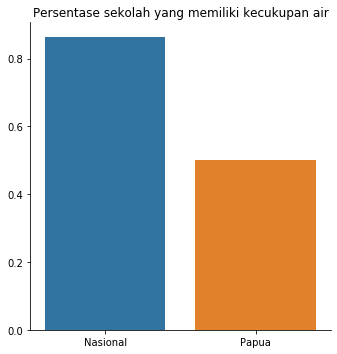

```python
get_bar(get_mean_categorical('is_water_enough'), 'is_water_enough_pct', 'Persentase sekolah yang memiliki kecukupan air')
```

### Memproses air

Tidak jelas maksudnya apa. Mohon pencerahannya 🙏🏽

```python
set(df['memproses_air'])
```

```
{'Tidak', 'Ya'}
```

```python
df['is_processing_water'] = df.apply(lambda x: x['memproses_air'] == 'Ya', axis=1)
```

```python
is_processing_water = df.groupby(['is_papua', 'is_processing_water'])['sekolah_id_enkrip'].agg('count').to_frame().reset_index()
is_processing_water
```

|  | is_papua | is_processing_water | sekolah_id_enkrip |
| --- | --- | --- | --- |
| 0 | False | False | 5969 |
| 1 | False | True | 1941 |
| 2 | True | False | 173 |
| 3 | True | True | 42 |

```python
get_mean_categorical('is_processing_water')
```

|  | is_papua | is_processing_water_pct |
| --- | --- | --- |
| 0 | False | 0.245386 |
| 1 | True | 0.195349 |

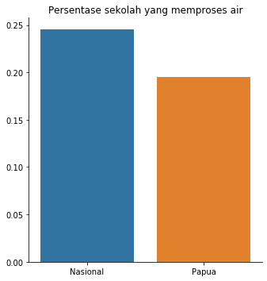

```python
get_bar(get_mean_categorical('is_processing_water'), 'is_processing_water_pct', 'Persentase sekolah yang memproses air')
```

### Minum siswa

```python
set(df['minum_siswa'])
```

```
{'Disediakan sekolah', 'Tidak disediakan'}
```

```python
df['provided_by_school'] = df.apply(lambda x: x['minum_siswa'] == 'Disediakan sekolah', axis=1)
```

```python
provided_by_school = df.groupby(['is_papua', 'provided_by_school'])['sekolah_id_enkrip'].agg('count').to_frame().reset_index()
provided_by_school
```

|  | is_papua | provided_by_school | sekolah_id_enkrip |
| --- | --- | --- | --- |
| 0 | False | False | 5634 |
| 1 | False | True | 2276 |
| 2 | True | False | 182 |
| 3 | True | True | 33 |

```python
get_mean_categorical('provided_by_school')
```

|  | is_papua | provided_by_school_pct |
| --- | --- | --- |
| 0 | False | 0.287737 |
| 1 | True | 0.153488 |

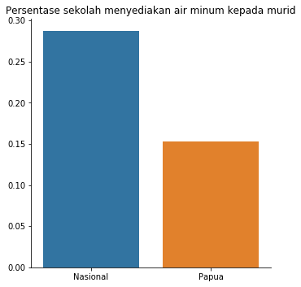

```python
get_bar(get_mean_categorical('provided_by_school'), 'provided_by_school_pct', 'Persentase sekolah yang menyediakan air minum kepada murid')
```

### Siswa bawa air

Maksudnya murid bawa air minum kali ya? Mohon pencerahannya. 🙏🏽

```python
set(df['siswa_bawa_air'])
```

```
{'Tidak', 'Ya'}
```

```python
df['students_bring_water'] = df.apply(lambda x: x['siswa_bawa_air'] == 'Ya', axis=1)
```

```python
students_bring_water = df.groupby(['is_papua', 'students_bring_water'])['sekolah_id_enkrip'].agg('count').to_frame().reset_index()
students_bring_water
```

|  | is_papua | students_bring_water | sekolah_id_enkrip |
| --- | --- | --- | --- |
| 0 | False | False | 3035 |
| 1 | False | True | 4875 |
| 2 | True | False | 153 |
| 3 | True | True | 62 |

```python
get_mean_categorical('students_bring_water')
```

|  | is_papua | students_bring_water_pct |
| --- | --- | --- |
| 0 | False | 0.616308 |
| 1 | True | 0.288372 |

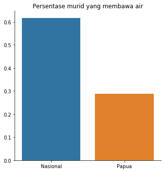

```python
get_bar(get_mean_categorical('students_bring_water'), 'students_bring_water_pct', 'Persentase murid yang membawa air')
```

### Toilet siswa berkebutuhan khusus

```python
get_mean('toilet_siswa_kk')
```

|  | is_papua | toilet_siswa_kk |
| --- | --- | --- |
| 0 | False | 0.606134 |
| 1 | True | 0.296651 |

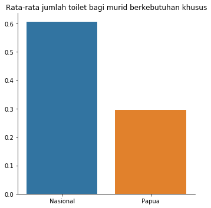

```python
get_bar(get_mean('toilet_siswa_kk'), 'toilet_siswa_kk', 'Rata-rata jumlah toilet bagi murid berkebutuhan khusus')
```

### Sumber air

```python
set(df['sumber_air_str'])
```

```
{'Air hujan',
 'Air kemasan',
 'Air sungai',
 'Lainnya',
 'Ledeng/PAM',
 'Mata air',
 'Mata air tdk terlindungi',
 'Mata air terlindungi',
 'Pompa',
 'Sumur terlindungi',
 'Sumur tidak terlindungi',
 nan}
```

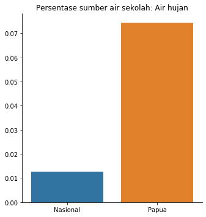

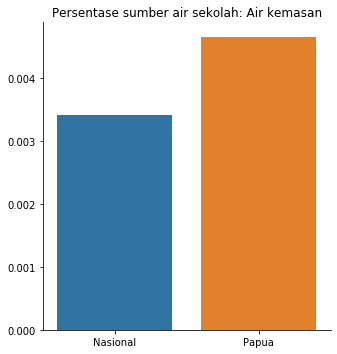

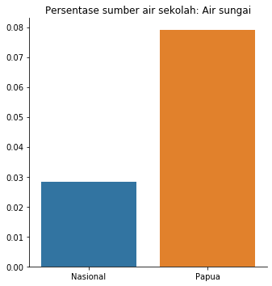

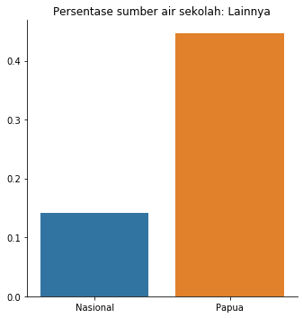

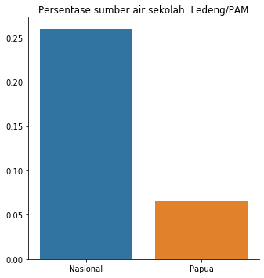

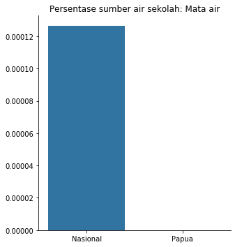

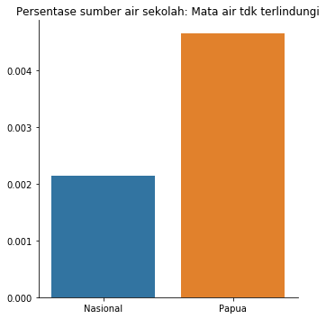

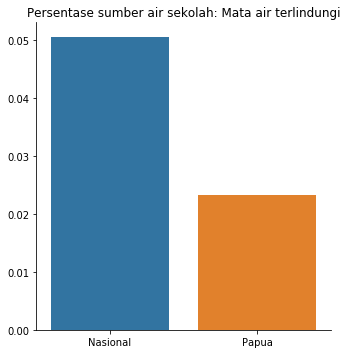

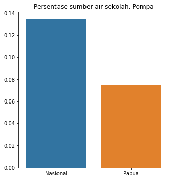

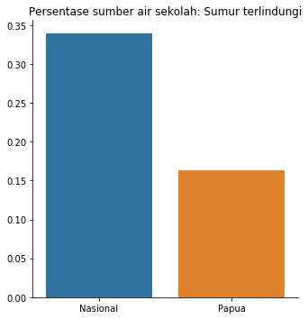

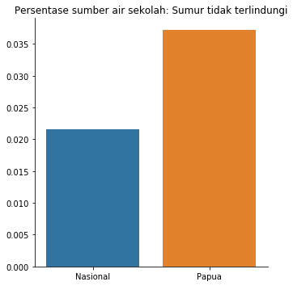

```python
get_bar_multiple('sumber_air_str', 'Persentase sumber air sekolah')
```

### Ketersediaan air

```python
set(df['ketersediaan_air'])
```

```
{'Tidak', 'Ya'}
```

```python
df['access_to_water'] = df.apply(lambda x: x['ketersediaan_air'] == 'Ya', axis=1)
```

```python
access_to_water = df.groupby(['is_papua', 'access_to_water'])['sekolah_id_enkrip'].agg('count').to_frame().reset_index()
access_to_water
```

|  | is_papua | access_to_water | sekolah_id_enkrip |
| --- | --- | --- | --- |
| 0 | False | False | 766 |
| 1 | False | True | 7144 |
| 2 | True | False | 84 |
| 3 | True | True | 131 |

```python
get_mean_categorical('access_to_water')
```

|  | is_papua | access_to_water_pct |
| --- | --- | --- |
| 0 | False | 0.903161 |
| 1 | True | 0.609302 |

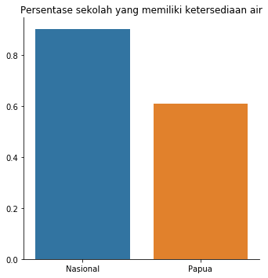

```python
get_bar(get_mean_categorical('access_to_water'), 'access_to_water_pct', 'Persentase sekolah yang memiliki ketersediaan air')
```

### Tipe jamban

```python
set(df['tipe_jamban'])
```

```
{'Cubluk dengan tutup',
 'Cubluk tanpa tutup',
 'Jamban menggantung di atas sungai',
 'Leher angsa (toilet duduk/jongkok)',
 'Tidak tersedia jamban'}
```

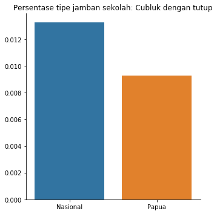

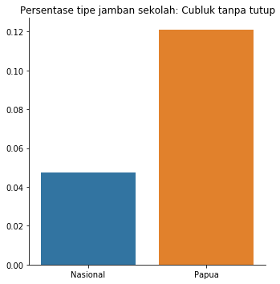

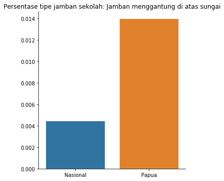

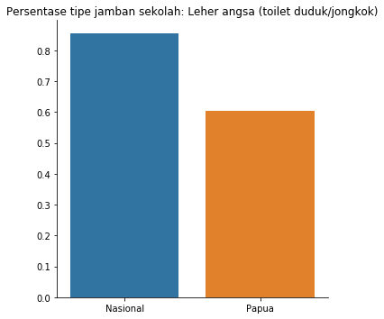

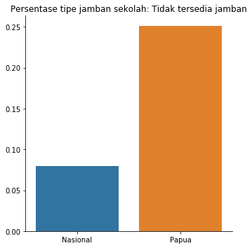

```python
get_bar_multiple('tipe_jamban', 'Persentase tipe jamban sekolah')
```

### Wastafel

```python
get_mean('jml_wastafel')
```

|  | is_papua | jml_wastafel |
| --- | --- | --- |
| 0 | False | 4.337618 |
| 1 | True | 1.602871 |

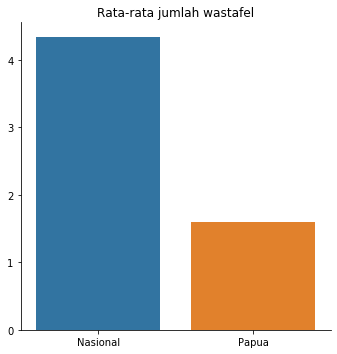

```python
get_bar(get_mean('jml_wastafel'), 'jml_wastafel', 'Rata-rata jumlah wastafel')
```

### Sabun dan air

```python
set(df['a_sabun_air_mengalir'])
```

```
{'Tidak', 'Ya'}
```

```python
df['water_and_soap'] = df.apply(lambda x: x['a_sabun_air_mengalir'] == 'Ya', axis=1)
```

```python
water_and_soap = df.groupby(['is_papua', 'water_and_soap'])['sekolah_id_enkrip'].agg('count').to_frame().reset_index()
water_and_soap
```

|  | is_papua | water_and_soap | sekolah_id_enkrip |
| --- | --- | --- | --- |
| 0 | False | False | 3212 |
| 1 | False | True | 4698 |
| 2 | True | False | 162 |
| 3 | True | True | 53 |

```python
get_mean_categorical('water_and_soap')
```

|  | is_papua | water_and_soap_pct |
| --- | --- | --- |
| 0 | False | 0.593932 |
| 1 | True | 0.246512 |

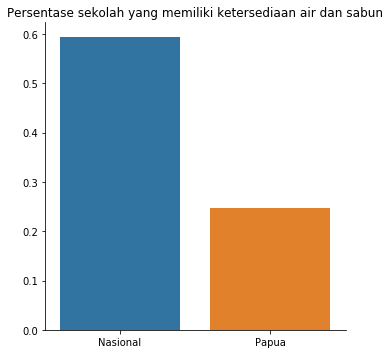

```python
get_bar(get_mean_categorical('water_and_soap'), 'water_and_soap_pct', 'Persentase sekolah yang memiliki ketersediaan air dan sabun')
```

### Jamban

```python
get_mean('jml_jamban_digunakan')
```

|  | is_papua | jml_jamban_digunakan |
| --- | --- | --- |
| 0 | False | 5.014539 |
| 1 | True | 2.553488 |

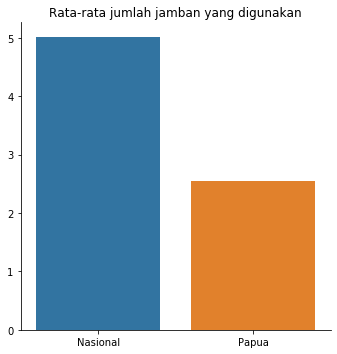

```python
get_bar(get_mean('jml_jamban_digunakan'), 'jml_jamban_digunakan', 'Rata-rata jumlah jamban yang digunakan')
```

```python
get_mean('jml_jamban_tidak_digunakan')
```

|  | is_papua | jml_jamban_tidak_digunakan |
| --- | --- | --- |
| 0 | False | 0.810367 |
| 1 | True | 0.818605 |

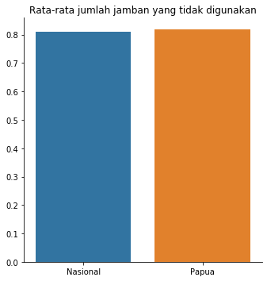

```python
get_bar(get_mean('jml_jamban_tidak_digunakan'), 'jml_jamban_tidak_digunakan', 'Rata-rata jumlah jamban yang tidak digunakan')
```

# Kesimpulan

Seperti yang sudah kita lihat, kondisi persekolahan di Papua dan Papua Barat jelas tertinggal jika dibandingkan dengan nasional dari beberapa aspek. Semoga dengan ini saya sebagai masyarakat kelas menengah ngehe dapat mengakui privilese hidup yang dikaruniai Tuhan YME. Demikian saya ucapkan wabillahi taufiq wal hidayah, wassalamualikum warahmatullahi wabarakatuh. 🙏🏽